# College Basketball Analysis

#### By Matt Schaefer - (Solo Project)

## 1. Introduction

Every spring, (those occurring during pandemics excepted), millions of Americans draw up brackets and bet on the success and failure of 64 college basketball teams in a postseason finale known as March Madness. No one has ever submitted a perfect bracket, and the odds of it happening are 2.4 trillion to one according to a [Duke math professor<sup>1</sup>](https://math.duke.edu/news/duke-math-professor-says-odds-perfect-bracket-are-one-24-trillion).

Sure, it’s highly unlikely even the best mathematical model will allow a person to flawless predict the outcome of the entire tournament. But what if we could build a model that would improve predictions enough to win a pool of brackets - the type so many people compete in every March.

This notebook will atttempt to do just that, first covering the process of tidying data found online, then doing Exploratory Data Analysis, then finally, creating a model to predict teams’ NCAA March Madness performance given their season record and tournament seed. We’ll go over a couple different ways to build the model and compare their efficacy.

The steps are as follows:

1. Data cleaning
   - Read & investigate data/entities/attributes
   - Add necessary attributes
   - Adjust postseason attribute so that it is represented as an integer value
   - Remove unnecessary attributes
   - Standardize continuous attributes
   - Partition data into a training and testing set
2. Exploratory Data Analysis
   - Univariate analysis
   - Bivariate analysis
   - Multivariate analysis
3. Model Building & Evaluationn
   - Decision Tree
   - Random Forest
4. Conclusions
5. Citations

### 1.2 Reading in data and evaluating its organization

Now that we are ready to work, we want to access our data and evaluate its organization. We use the read_csv function to read the data which we’ve downloaded via csv file, when the glimpse function to get a quick look at how the data is organized.

```r
bball_tab <- read_csv("~/CMSC320-Final-Project/cbb.csv", col_types = cols()) # read in data
glimpse(bball_tab) # observe entity and attribute types
```

```
## Observations: 1,757
## Variables: 24
## $ TEAM       <chr> "North Carolina", "Wisconsin", "Michigan", "Texas Tech", "…
## $ CONF       <chr> "ACC", "B10", "B10", "B12", "WCC", "ACC", "ACC", "ACC", "B…
## $ G          <dbl> 40, 40, 40, 38, 39, 39, 38, 39, 40, 40, 36, 38, 36, 37, 37…
## $ W          <dbl> 33, 36, 33, 31, 37, 35, 35, 33, 35, 36, 27, 32, 24, 29, 29…
## $ ADJOE      <dbl> 123.3, 129.1, 114.4, 115.2, 117.8, 125.2, 123.0, 121.0, 12…
## $ ADJDE      <dbl> 94.9, 93.6, 90.4, 85.2, 86.3, 90.6, 89.9, 91.5, 90.9, 94.1…
## $ BARTHAG    <dbl> 0.9531, 0.9758, 0.9375, 0.9696, 0.9728, 0.9764, 0.9736, 0.…
## $ EFG_O      <dbl> 52.6, 54.8, 53.9, 53.5, 56.6, 56.6, 55.2, 51.7, 56.1, 59.5…
## $ EFG_D      <dbl> 48.1, 47.7, 47.7, 43.0, 41.1, 46.5, 44.7, 48.1, 46.7, 48.5…
## $ TOR        <dbl> 15.4, 12.4, 14.0, 17.7, 16.2, 16.3, 14.7, 16.2, 16.3, 15.0…
## $ TORD       <dbl> 18.2, 15.8, 19.5, 22.8, 17.1, 18.6, 17.5, 18.6, 20.6, 18.2…
## $ ORB        <dbl> 40.7, 32.1, 25.5, 27.4, 30.0, 35.8, 30.4, 41.3, 28.2, 29.6…
## $ DRB        <dbl> 30.0, 23.7, 24.9, 28.7, 26.2, 30.2, 25.4, 25.0, 29.4, 27.1…
## $ FTR        <dbl> 32.3, 36.2, 30.7, 32.9, 39.0, 39.8, 29.1, 34.3, 34.1, 29.4…
## $ FTRD       <dbl> 30.4, 22.4, 30.0, 36.6, 26.9, 23.9, 26.3, 31.6, 30.0, 26.7…
## $ `2P_O`     <dbl> 53.9, 54.8, 54.7, 52.8, 56.3, 55.9, 52.5, 51.0, 57.4, 59.0…
## $ `2P_D`     <dbl> 44.6, 44.7, 46.8, 41.9, 40.0, 46.3, 45.7, 46.3, 44.1, 49.0…
## $ `3P_O`     <dbl> 32.7, 36.5, 35.2, 36.5, 38.2, 38.7, 39.5, 35.5, 36.2, 40.1…
## $ `3P_D`     <dbl> 36.2, 37.5, 33.2, 29.7, 29.0, 31.4, 28.9, 33.9, 33.9, 31.7…
## $ ADJ_T      <dbl> 71.7, 59.3, 65.9, 67.5, 71.5, 66.4, 60.7, 72.8, 66.7, 69.6…
## $ WAB        <dbl> 8.6, 11.3, 6.9, 7.0, 7.7, 10.7, 11.1, 8.4, 8.9, 10.6, 5.8,…
## $ POSTSEASON <chr> "2ND", "2ND", "2ND", "2ND", "2ND", "Champions", "Champions…
## $ SEED       <dbl> 1, 1, 3, 3, 1, 1, 1, 1, 2, 1, 4, 3, 6, 1, 2, 9, 1, 3, 1, 1…
## $ YEAR       <dbl> 2016, 2015, 2018, 2019, 2017, 2015, 2019, 2017, 2016, 2018…
```

We want to see whether the data is tidy. This means that each row contains 1 entity and each column represents 1 attribute. Basically, an entity is a real life ‘object’ while an attribute describes such an object. In our case, an entity is a college basketball team in a single season. Our attributes include the team’s name, conference, and stats describing their performance. For more information on the distinction between entities and attributes, [here is a useful site<sup>3</sup>](https://binaryterms.com/difference-between-entity-and-attribute-in-database.html). We see with the glimpse command that our data is already tidy. We also see that there are 1757entities with 24 attributes each. 21 of these attributes are doubles while the remaining three are characters. The ‘POSTSEASON’ attribute is of special interest to us, since this is the aspect we are aiming to predict.

### 1.3 Investigate attributes

Now that we know a bit more about the data’s organization, we want to make sure we understand the data’s attributes and what they each mean. A full description can be found on [kaggle<sup>4</sup>](https://www.kaggle.com/andrewsundberg/college-basketball-dataset), where we downloaded our data set, but below is a summarization. I’ve also included a classification for each attribute. Some common attribute types include text, continuous and discrete numeric, and unordered/ordered categorical. Click [here<sup>5</sup>](https://www.geeksforgeeks.org/understanding-data-attribute-types-qualitative-and-quantitative/) for a detailed description of types of attributes and their differences.

- TEAM - team/school name (text-nominal)
- CONF - conference id (text-nominal)
- G - games played (discrete numeric)
- W - wins (discrete numeric)
- ADJOE - points scored per 100 possessions (continuous numeric)
- ADJDE - points allowed per 100 possessions (continuous numeric)
- BARTHAG - probability of beating avg. DIV I team (continuous numeric)
- EFG_O - field goal pctg (continuous numeric)
- EFG_D - defensive field goal pctg (continuous numeric)
- TOR - turnover rate (continuous numeric)
- TORD - steal rate (continuous numeric)
- ORB - offensive rebound pctg (continuous numeric)
- DRB - defensive rebound pctg (continuous numeric)
- FTR - free throw pctg (continuous numeric)
- FTRD - defensive free throw pctg (continuous numeric)
- 2P0 - 2 point shooting pctg (continuous numeric)
- 2PD - defensive 2 point shooting pctg (continuous numeric)
- 3P0 - 3 point shooting pctg (continuous numeric)
- 3PD - defensive 3 point shooting pctg (continuous numeric)
- ADJ_T - possessions per 40 minutes (continuous numeric)
- WAB - wins above necessary amount to qualify for postseason (discrete numeric)
- POSTSEASON - round of the postseason the team made it to (ordered categorical)
- SEED - tournament seed (discrete numeric)
- YEAR - season of play/tournament (discrete numeric)

### 1.4 Add attributes

In order to work with our data, we need to adjust some of the given attributes and tweak some of the data. Remember, our goal is to predict postseason performance. Hypothetically, before a tournament we will already know we don’t have to worry about teams that did not make the cut, so we will disregard those teams and eliminate them from our data set (their postseason attribute is listed as NA). We also want to change our postseason attribute from categorical unordered (represented by a text string) to a numerical attribute, so it is easier to graph. Finally, we want to replace Wins and Games with a better metric with which we can compare teams, so we add win-loss ratio.

```r
clean_bball <- bball_tab %>%
  filter(!is.na(`POSTSEASON`)) %>% # filter out teams that did not make the postseason
  mutate(pstsn_rank=0) %>% # create a new numerical attribute to represent postseason performance
  mutate(win_ratio=W/(G-W)) # add a win-loss ratio as an attribute
```

Next, we take the text attribute, POSTSEASON, of the original table and assign a corresponding number to each entity. The champion is assigned 7, the second place team 6, teams who made it to the semi finals 5, and so on.

```r
for (i in 1:340) {
  j<-clean_bball[i,"POSTSEASON"]
  if(j=="Champions"){
    clean_bball[i,"pstsn_rank"]<-7
  } else if(clean_bball[i,"POSTSEASON"]=="2ND"){
    clean_bball[i,"pstsn_rank"]<-6
  } else if(clean_bball[i,"POSTSEASON"]=="F4"){
    clean_bball[i,"pstsn_rank"]<-5
  } else if(clean_bball[i,"POSTSEASON"]=="E8"){
    clean_bball[i,"pstsn_rank"]<-4
  } else if(clean_bball[i,"POSTSEASON"]=="S16"){
    clean_bball[i,"pstsn_rank"]<-3
  } else if(clean_bball[i,"POSTSEASON"]=="R32"){
    clean_bball[i,"pstsn_rank"]<-2
  } else if(clean_bball[i,"POSTSEASON"]=="R64"){
    clean_bball[i,"pstsn_rank"]<-1
  } else {
    clean_bball[i,"pstsn_rank"]<-0
  }
}
```

### 1.5 Remove unnecessary attributes

We remove all attributes that do not impact our analysis, including team, conference, and year. For simplicity’s sake, we also remove attributes that intuitively are less important to the outcome of the tournament: EFG_O, EFG_D, TOR, TORD, ORB, DRB, FTR, FTRD, 2P0, 2PD, 3P0, 3PD, ADJ_T, and WAB. It also includes games, wins, and postseason since we have effectively replaced these attributes.

```r
ncaa_tab <- clean_bball[,c(26,25,23,1,2,3,4,5,6,7,8,9,10,11,12,13,14,15,16,17,18,19,20,21,22,24)]
ncaa_tab <- subset(ncaa_tab, select = -c(TEAM,CONF,G,W,POSTSEASON,YEAR,EFG_O, EFG_D, TOR, TORD, ORB, DRB, FTR,
                                         FTRD, ADJ_T, WAB))
ncaa_tab <- ncaa_tab[-7]
ncaa_tab <- ncaa_tab[-7]
ncaa_tab <- ncaa_tab[-7]
ncaa_tab <- ncaa_tab[-7]
```

### 1.6 Standardize continuous data

When graphing and looking for relationships in a set data, it is advantageous for it to be distributed normally. Oftentimes, the best way to ensure data is easy to graph is by centering (setting the mean to 0) and scaling (setting standard devation to 1) the data. This way, it becomes fairly evenly distributed, and it also shows trends more clearly than when an outlier may have skewed the data range. Below, we scale and center all the continuous numeric attributes in our set. Click [this link<sup>6</sup>](https://www.youtube.com/watch?time_continue=958&v=Vv69uhUiGU4&feature=emb_logo) for a video explaining the merits of this process (it’s a bit long, though).

```r
ncaa_tab<-ncaa_tab %>%
  mutate(std_winrat=(win_ratio-mean(win_ratio))/(sd(win_ratio))) %>%
  mutate(std_adjoe=(ADJOE-mean(ADJOE))/(sd(ADJOE))) %>%
  mutate(std_adjde=(ADJDE-mean(ADJDE))/(sd(ADJDE))) %>%
  mutate(std_barthag=(BARTHAG-mean(BARTHAG))/(sd(BARTHAG)))
```

Now on to the next phase!

## 2. Exploratory Data Analysis

For our EDA, we’ll use the entire data set to get the best representation of the data. Our goal is to see general trends in the data and observe relationships between attributes.

We will mainly be using the ggplot2 library to do our plotting. Documentation can be found [here<sup>7</sup>](https://ggplot2.tidyverse.org/). We also utilize the vioplot library for violin plots. Documentation for this library can be found [here<sup>8</sup>](https://cran.r-project.org/web/packages/vioplot/index.html).

### 2.1 Univariate analysis

First, we look at the univariate distributions. This entails observing distributions of individual attributes.

Below we look at the univariate distribution of tournament placement. Since the data can only be one of eight values (this attribute is discrete numerical), we will use a histogram:

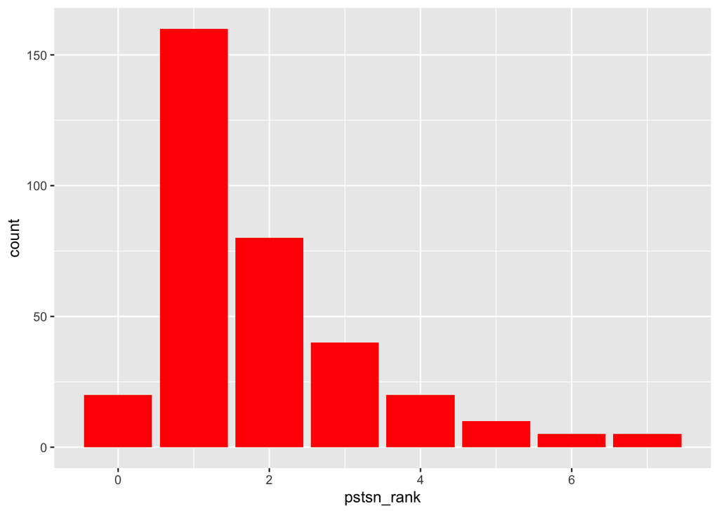

```r
ncaa_tab %>%
  ggplot(aes(x=pstsn_rank)) +
  geom_histogram(stat="count",fill="red")
```

Based on the way the tournament works, the data is distibuted as expected. A handful of the lower ranking teams are eliminated in [qualifying games<sup>9</sup>](https://ftw.usatoday.com/2018/03/march-madness-ncaa-tournament-no-11-seed-first-four-play-in-16-bracket-rules-selection), then elimination works as a factor of $TotalData*(\frac{1}{2})^r$ where r is rank.

Next we look at distribution of seed similarly via a histogram:

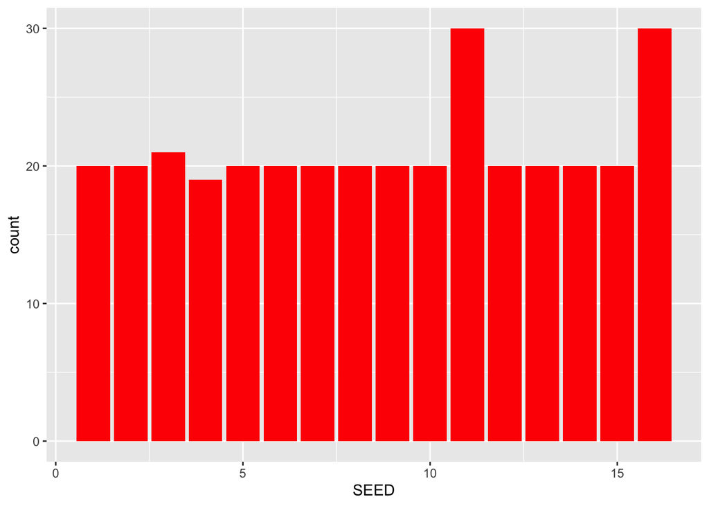

```r
ncaa_tab %>%
  ggplot(aes(x=SEED)) +
  geom_histogram(stat="count",fill="red")
```

For the most part, seed is uniformly distributed. Notable exceptions are 11th and 16th seed, as they compete in the aforementioned pre-qualifying round where 68 teams are narrowed to 64.

Now, let’s take a look at win-loss ratio. This data is cannot be counted the same way as the above data since team’s win loss ratios are continuous instead of discrete, so this time we’ll use a density plot.

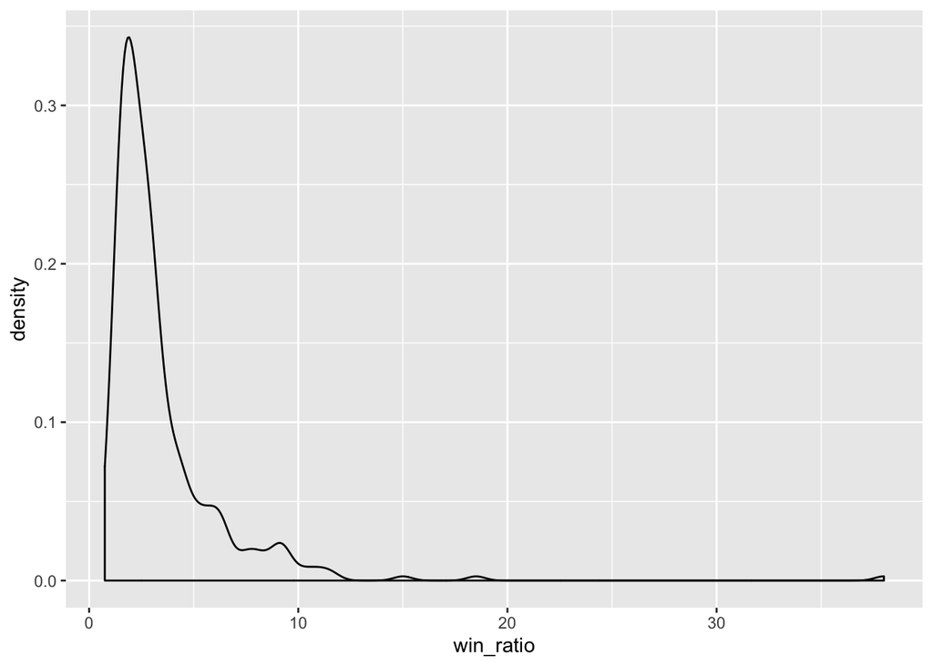

```r
ncaa_tab %>%
  ggplot(aes(x=win_ratio)) +
    geom_density()
```

We can see that data is not well centered; it seems most teams win-loss ratios are ~2, and several outliers are much greater than the majority of the data, thus we will use a slightly better representation, the standardized win-loss:

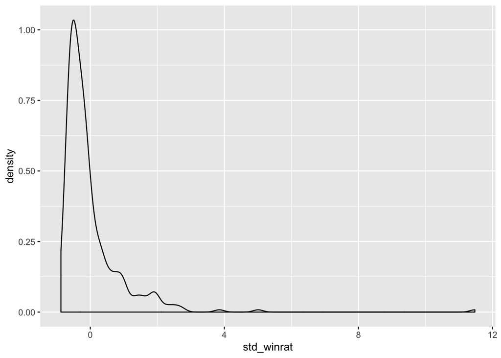

```r
ncaa_tab %>%
  ggplot(aes(x=std_winrat)) +
    geom_density()
```

Next, we look at offensive and defensive efficiency. We can view them on the same plot, since both use the same metric: points (for and against) per 100 possessions. Rather than using a density plot, we’ll use a different vizualiation which allows us to see the median directly as well as the distribution of data and the presence of outliers - violin plots:

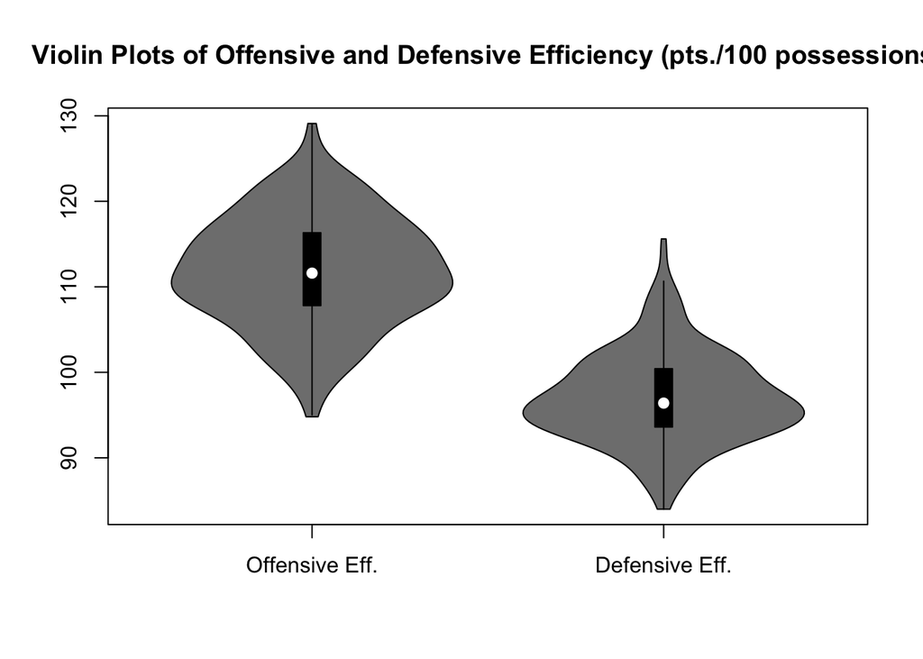

```r
vioplot(ncaa_tab$ADJOE, ncaa_tab$ADJDE, names=c("Offensive Eff.","Defensive Eff."))
title("Violin Plots of Offensive and Defensive Efficiency (pts./100 possessions)")
```

Outliers would show up on violin plots as points off to the ends of the violin shapes. These violin plots show that teams are distributed very normally by their offensive/defensive efficiency, with little to no skew since there are no outliers visible. The shape and positioning of the white circle shows a clear concentration of data at the median. The plots also shows that teams are generally more efficient offensively relative to defensively. This makes sense, since the teams in our dataset performed highly relative to the rest of the nation in order to qualify for the tournament, implying that a majority of the time, they must score more points per 100 possessions than are scored against them. [Here<sup>10</sup>](https://mode.com/blog/violin-plot-examples/) is a helpful resource which gives a bit more detail on violin plots.

While the standardized data does not show the disparity, it will make it easier to compare entities. Thus, below is the corresponding violin plot:

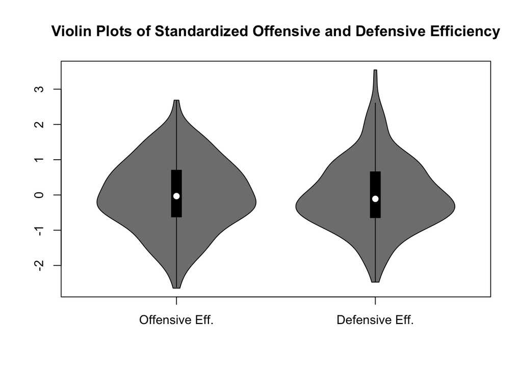

```r
vioplot(ncaa_tab$std_adjoe, ncaa_tab$std_adjde, names=c("Offensive Eff.","Defensive Eff."))
title("Violin Plots of Standardized Offensive and Defensive Efficiency")
```

We can observe that both data sets are centered at zero and distributed fairly evenly (since std dev = 1).

Lastly, we observe BARTHAG, or teams’ probability of beating an average Division I team:

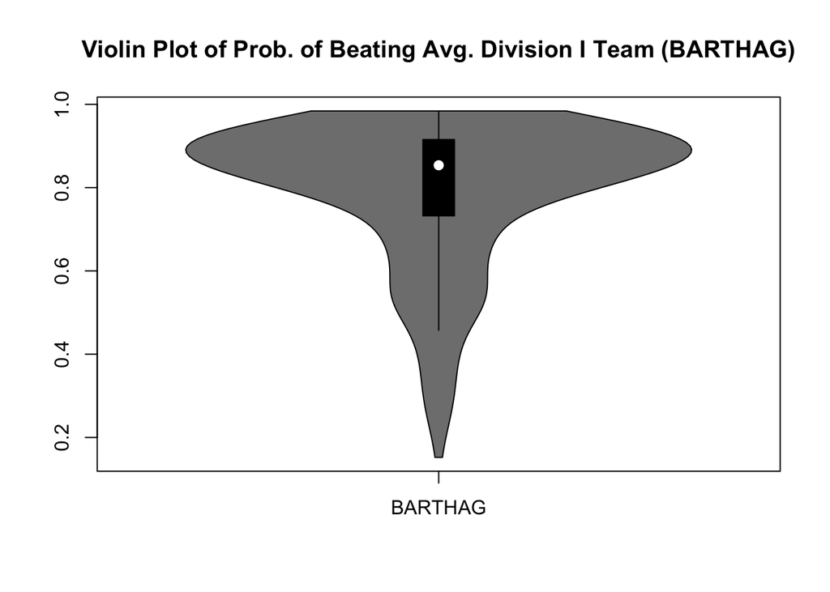

```r
vioplot(ncaa_tab$BARTHAG, names=c("BARTHAG"))
title("Violin Plot of Prob. of Beating Avg. Division I Team (BARTHAG)")
```

Again, we see that there are no outliers, however, based on the long tail in the negative direction, we can see that this data is skewed negatively. As we might guess, (since this is a collection of the best ranked teams), the data is clustered above .8, showing how a sizeable majority of teams in the tournament have a very good chance of defeating an average DI team.

To work with this stat better, let’s look at the standardized version:

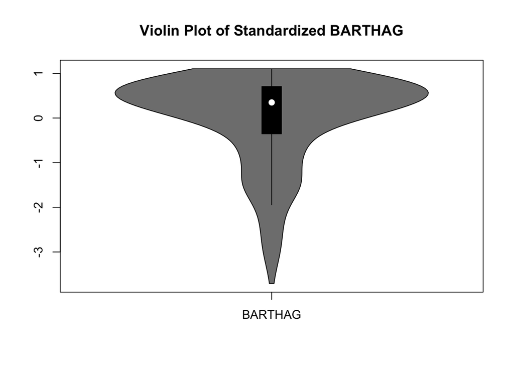

```r
vioplot(ncaa_tab$std_barthag, names=c("BARTHAG"))
title("Violin Plot of Standardized BARTHAG")
```

The data is now centered nearer to zero, however, the negative skew still prevents a normal distribution.

### 2.2 Bivariate analysis

Now, we’ll look at how each variable impacts team’s postseason performance by plotting postseason rank on the y axis and the other attributes on the x axis.

Here is the relationship between seed and postseason performance using a scatter plot. We also use the geom_smooth() command with the linear methond (lm) to approximate a linear relationship:

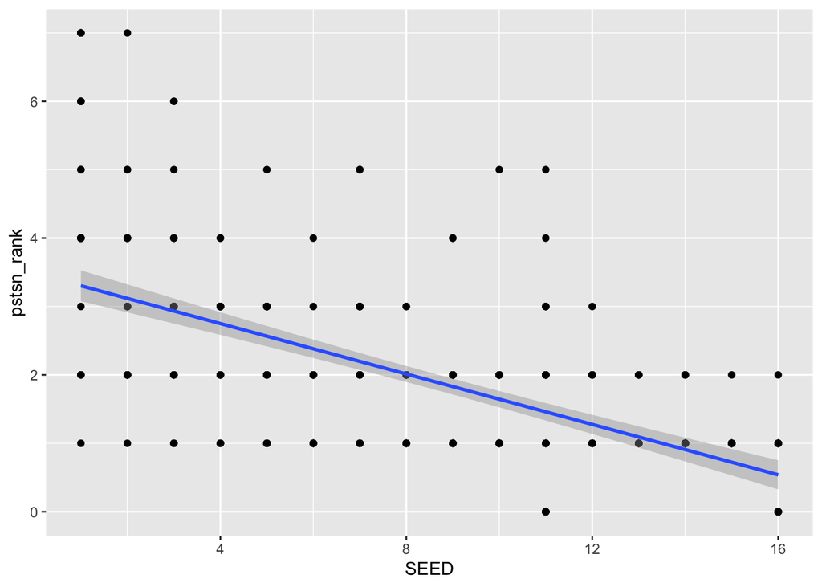

```r
ncaa_tab %>%
  ggplot(aes(x=SEED,y=pstsn_rank)) +
  geom_point() +
  geom_smooth(method=lm)
```

This graph and the linear approximation shows us that the lower number a seed is, the better they perform in the tournament. This is intuitive, since better ranked teams are seeded lower.

Now we observe how win-loss rate affects postseason performance similarly using a scatter plot and a linear approximation:

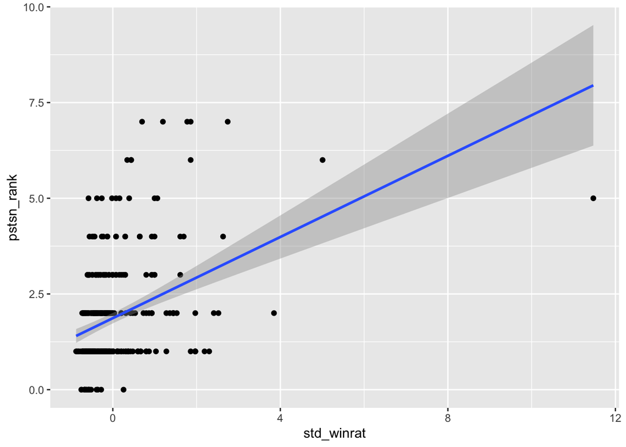

```r
ncaa_tab %>%
  ggplot(aes(x=std_winrat,y=pstsn_rank)) +
  geom_point() +
  geom_smooth(method=lm)
```

We repeat for barthag:

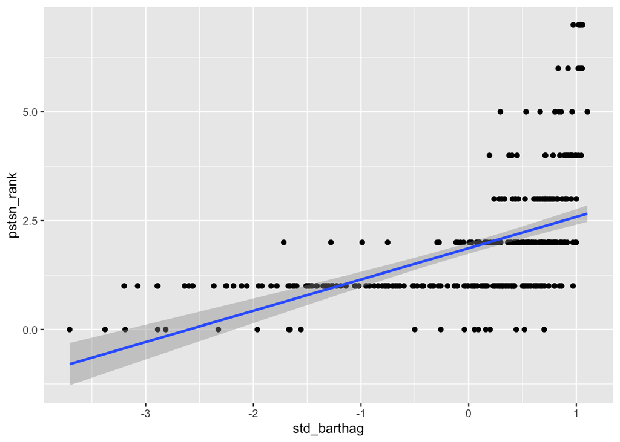

```r
ncaa_tab %>%
  ggplot(aes(x=std_barthag,y=pstsn_rank)) +
  geom_point() +
  geom_smooth(method=lm)
```

Again, our linear relationship is intuitive, as one would expect a higher chance of defeating an average team would correlate with a better postseason performance.

We repeat for offensive efficiency:

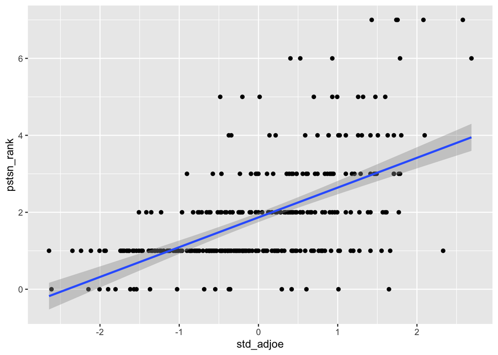

```r
ncaa_tab %>%
  ggplot(aes(x=std_adjoe,y=pstsn_rank)) +
  geom_point() +
  geom_smooth(method=lm)
```

Again, our result makes sense since a more efficient offense will allow a team to perfom better in the tournament.

We repeat again for defensive efficiency:

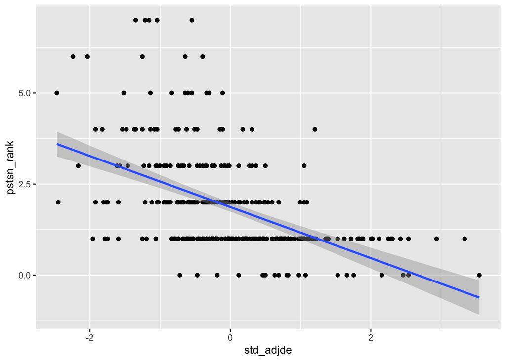

```r
ncaa_tab %>%
  ggplot(aes(x=std_adjde,y=pstsn_rank)) +
  geom_point() +
  geom_smooth(method=lm)
```

Yet again, the relationship makes sense since fewer points against on average will allow a team to perform better in the tournament.

### 2.3 Multivariate analysis

For this, we will observe how seeding affects the relationships between other attributes and postseason performance.

Note that the general trend observed in the bivariate analysis above showed that a lower seed corresponded with a better performance in the tournament on average.

For this section, we’ll repeat the scatter plots used above omitting the one corresponding to seed, this time incorporating the seed attribute into each plot using the color option in ggplot2.

This allows us to see the conditional relationship between postseason performance and each attribute conditioning on their seed. [This resource<sup>11</sup>](https://www.mathsisfun.com/data/probability-events-conditional.html) gives more information on conditional probabilities.

Below, we see that teams with high win-loss rate which have better postseason records are generally overlap with the teams have a low seed and vice versa.

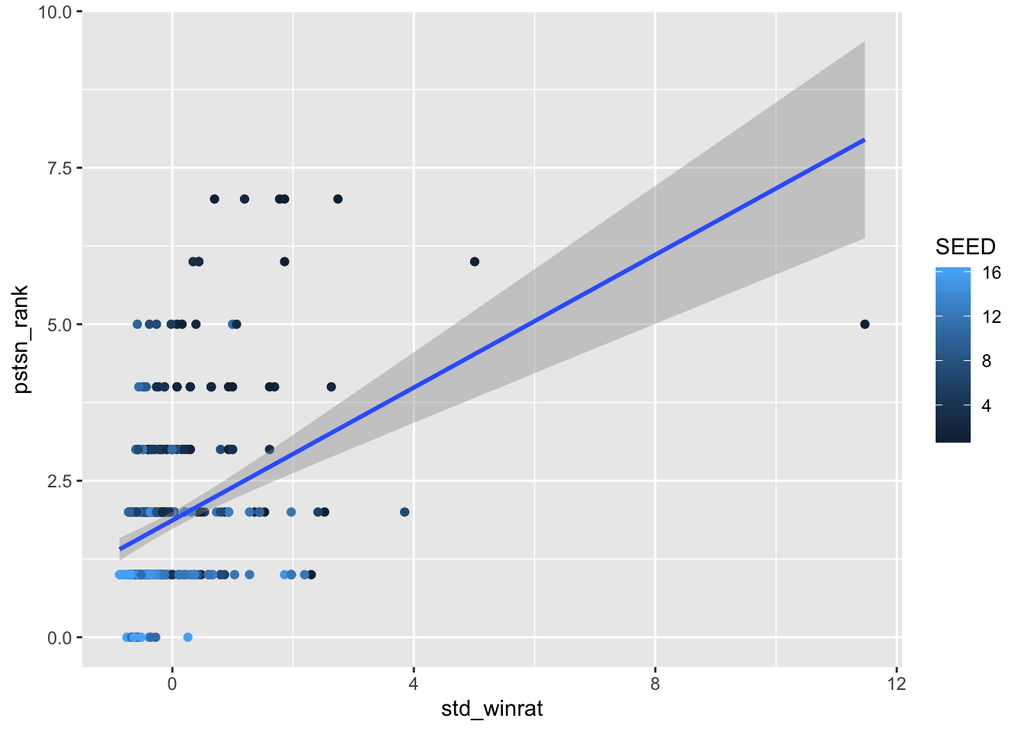

```r
ncaa_tab %>%
  ggplot(aes(x=std_winrat,y=pstsn_rank, color=SEED)) +
  geom_point() +
  geom_smooth(method=lm)
```

The same convergent trend can be seen here:

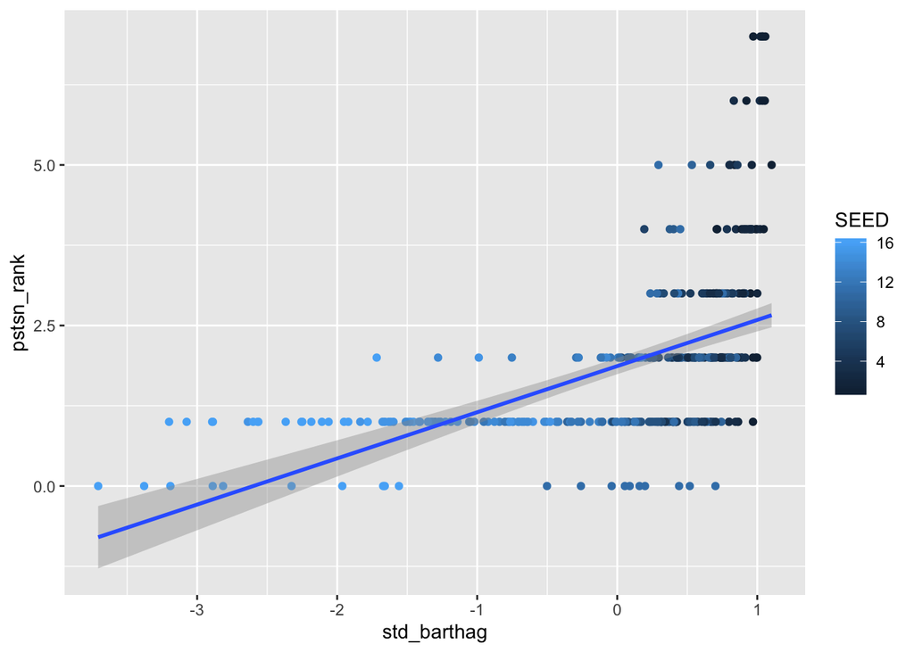

```r
ncaa_tab %>%
  ggplot(aes(x=std_barthag,y=pstsn_rank, color=SEED)) +
  geom_point() +
  geom_smooth(method=lm)
```

We see that a better chance of beating an avg. Div I team corresponds with better postseason performance, and the improved performance corresponds with the teams with lower seeds.

Below we again observe the same pattern regarding offensive efficiency:

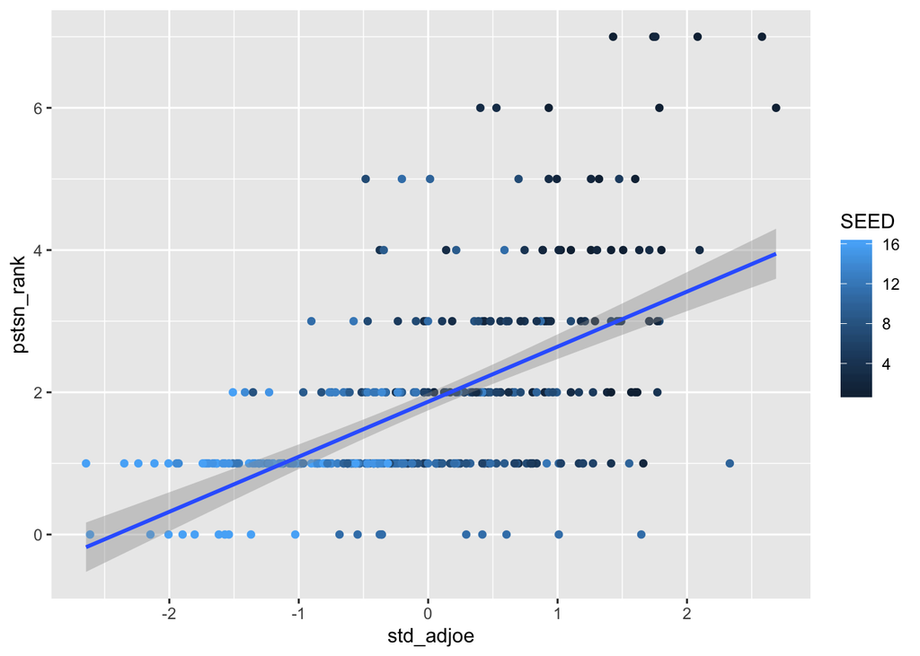

```r
ncaa_tab %>%
  ggplot(aes(x=std_adjoe,y=pstsn_rank, color=SEED)) +
  geom_point() +
  geom_smooth(method=lm)
```

And again with defensive efficiency:

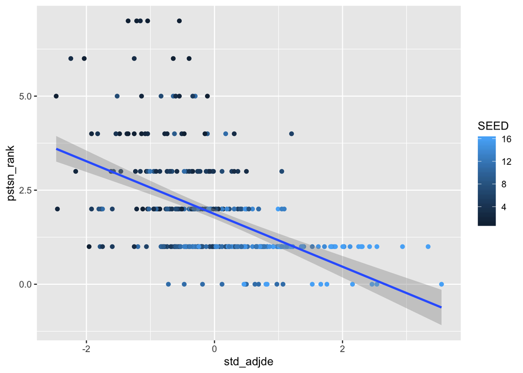

```r
ncaa_tab %>%
  ggplot(aes(x=std_adjde,y=pstsn_rank, color=SEED)) +
  geom_point() +
  geom_smooth(method=lm)
```

Based on the bivariate and multivariate analyses, it’s clear that there is correlation between each attribute and postseason performance. However, it’s not clear whether these attributes independently influence postseason performance or whether some cause others leading all of them to show correlation. Based on these findings, our model will take all attributes (seed, win ratio, offensive efficiency, defensive efficiency and BARTHAG) into account

## 3. Model Building & Evaluation

From now on, we’ll use our standardized data, so we drop our unstandardized data:

```r
ncaa_tab <- subset(ncaa_tab, select = -c(ADJOE,ADJDE,BARTHAG,win_ratio)) # dropping columns
```

The first classification we will use is a decision tree. As explained in a [Towards Data Science article<sup>12</sup>](https://towardsdatascience.com/decision-trees-in-machine-learning-641b9c4e8052), a decision tree is “drawn upside-down with its root at the top.” Essentially, the structure represents the model’s prediction algorithm. At every node there is a condition, and the predicted outcome is found by going to the leaf that corresponds to the entity’s data. There are two main types of decision trees: classification and regression trees. Classification tree aim to predict categorical attributes, whereas we are predicting a numerical attribute, so the type we use in this case is a regression tree. Essentially, it takes several attributes into account and partitions the data in ways that split the data into significant chunks by set values of the attributes. After a tree is synthesized, it often needs to be ‘pruned.’ This refers to the process of discarding the negligibly important decisions from the tree.

Advantages of decision trees include easy vizualization, implicitly selecting which features to include in predictions, compatability with numerical and categorical data, and ability to work with non-linear relationships. Disadvantages include potentially overfitting data, instability, and biases due to a select few classes taking up most of the decisions.

Here is code for and example of the type of decision tree we will be using, as well as a visual representation of it using all of our available data:

```r
tree<-rpart(pstsn_rank~SEED+std_winrat+std_adjoe+std_adjde+std_barthag,data=ncaa_tab) # create tree, mapping
# all other attributes to predict pstsn_rank, use ncaa_tab data
prune.rpart(tree=tree,cp=NULL) # prune less important decisions off of tree
```

```
## n= 340
##
## node), split, n, deviance, yval
##       * denotes terminal node
##
##   1) root 340 649.044100 1.867647
##     2) std_barthag< 0.7056552 255 193.858800 1.376471
##       4) std_barthag< 0.1721133 135  34.933330 1.022222 *
##       5) std_barthag>=0.1721133 120 122.925000 1.775000
##        10) std_winrat< -0.6092431 21   8.571429 1.142857 *
##        11) std_winrat>=-0.6092431 99 104.181800 1.909091 *
##     3) std_barthag>=0.7056552 85 209.105900 3.341176
##       6) std_barthag< 1.009133 75 122.000000 3.000000
##        12) std_barthag< 0.7998777 27  18.740740 2.518519 *
##        13) std_barthag>=0.7998777 48  93.479170 3.270833
##          26) std_adjde< -1.596109 7   2.857143 2.142857 *
##          27) std_adjde>=-1.596109 41  80.195120 3.463415
##            54) std_barthag< 0.9186674 28  50.107140 3.178571
##             108) std_barthag>=0.8414974 18  23.111110 2.777778 *
##             109) std_barthag< 0.8414974 10  18.900000 3.900000 *
##            55) std_barthag>=0.9186674 13  22.923080 4.076923 *
##       7) std_barthag>=1.009133 10  12.900000 5.900000 *
```

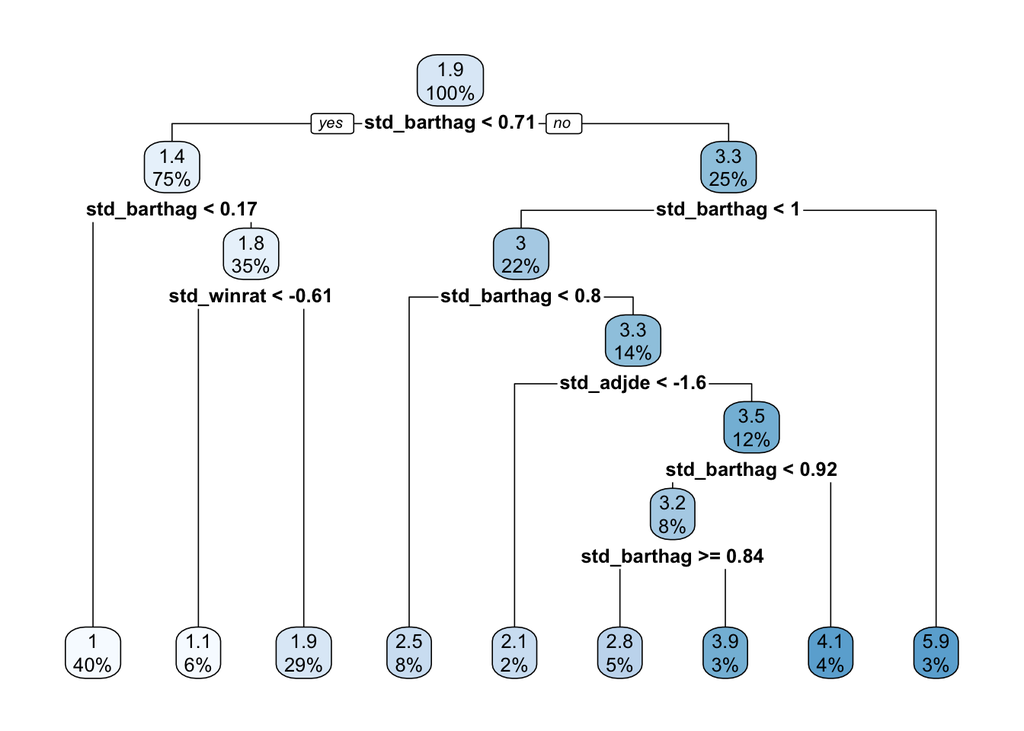

```r
rpart.plot(tree) # plot the tree below
```

As you can see in the visualization, the tree uses significant cutoff points found in the attributes fed into the tree in order to reach a conclusion about the predicted postseason rank of any given team.

The other model we will be evaluating is the random forest. This type of model, described generally in [this Medium article](https://medium.com/@Synced/how-random-forest-algorithm-works-in-machine-learning-3c0fe15b6674^13^), generates many trees using different combinations of the data. The random forest also uses a random selection of the attributes. In this way, it avoids the potential bias of a decision tree. However, due to its complex synthesis of many trees, it cannot be visually represented as easily. For a more in-depth description of the intricacies of the random forest model, Berkely has a [really detailed page<sup>14</sup>](https://www.stat.berkeley.edu/~breiman/RandomForests/cc_home.htm).

Here is an example of what the code to generate a random forest would look like:

```r
rand_forest <- randomForest(pstsn_rank~SEED+std_winrat+std_adjoe+std_adjde+std_barthag, importance=TRUE, mtry=3, data=ncaa_tab) # create random forest predicting postseason performance using all other attributes
```

As we said, the random forest sacrifices interpretability. However, the importance plot allows us to see which attributes are most integral to our prediction. Below is our code to get the importance plot followed by the plot itself.

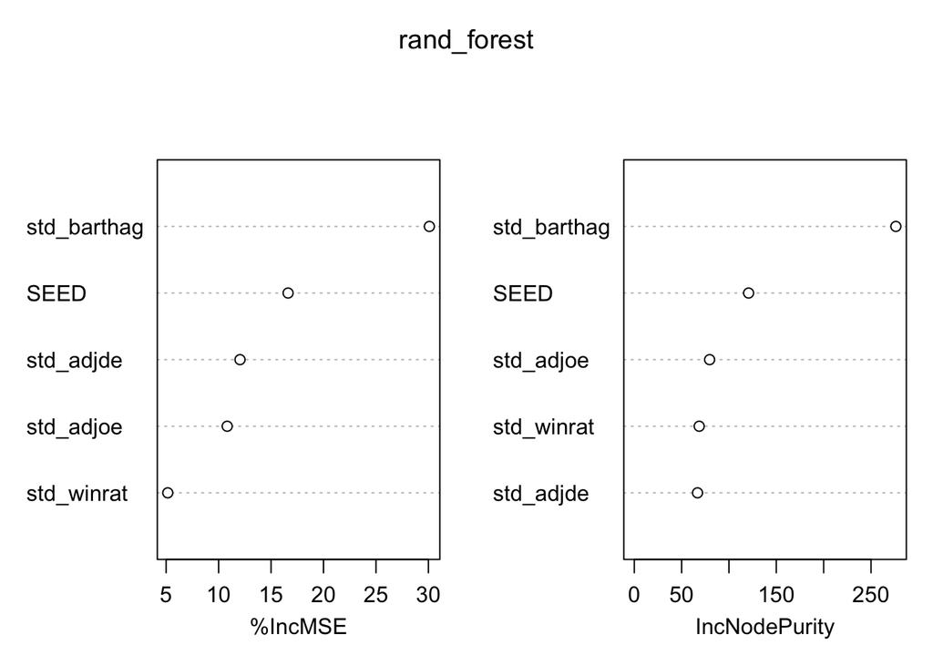

```r
varImpPlot(rand_forest) # plot importance of rand forest
```

From this plot, we can see that barthag and SEED are the attributes emphasized by our model the most.

Now that we have covered the basics of both of our classification models, our next step is to compare the efficacy of the two. In order to do this, we will use k-fold cross validation.

The idea behind this is based on developing a model using one dataset then testing the efficacy on a separate data set, as described on [this<sup>15</sup>](https://machinelearningmastery.com/difference-test-validation-datasets/) Machine Learning Mastery page. This is necessary, since the model will be fitted to the data it is trained with, so you can’t test it with the same data.

What k-fold cross validation does is it repeats this process k times by dividing the full dataset into k partitions and using one partition as a testing set at a time while using the remaining sets to train the models. [This site<sup>16</sup>](https://machinelearningmastery.com/k-fold-cross-validation/) gives a really thorough overview of the process.

Below, we go about the process of running 10-fold cross validation to compare a decision tree and a random forest.

```r
set.seed(1234) # set seed to make partitions reproducible

fold_indices <- cvFolds(n=nrow(ncaa_tab), K=10) # get indices where data is partitioned

error_rates_bytwo <- sapply(1:10, function(fold_index) { # this function loads the error stats into a dataframe
  test_indices <- which(fold_indices$which == fold_index)
  test_set <- ncaa_tab[test_indices,] # this defines the test set
  train_set <- ncaa_tab[-test_indices,] # this defines the training set

  forest = randomForest(x = train_set[-1], y = train_set$pstsn_rank,
                          ntree = 500, random_state = 0) # This code trains a 500 tree random forest training all
                          # attributes to predict pstsn_rank using training data
  forest_pred = predict(forest, newdata = test_set[-1], type="response") # this generates the predictions of
                          # postseason rank based on the test data
  forest_error <- mean(abs(test_set$pstsn_rank - round(forest_pred))>=2) # this calculates the proportion of
                          # errors per prediction for the current fold giving a 1 off leeway by defining an
                          # error as when a prediction is off by more than 1

  tree <- rpart(pstsn_rank~SEED+std_winrat+std_adjoe+std_adjde+std_barthag, data=train_set) # This code trains a
                          # decision tree to use all attributes to predict pstsn_rank using training data
  tree_pred <- predict(tree, newdata=test_set, type="vector") # generates predictions based on test data
  tree_error <-  mean(abs(test_set$pstsn_rank - round(tree_pred))>=2) # this calculates the proportion of
                          # errors per prediction for the current fold giving a 1 off leeway by defining an
                          # error as when a prediction is off by more than 1
  forest_error1 <- mean(test_set$pstsn_rank != round(forest_pred)) # this calculates error as strictly whether
                          # prediction does not equal actual
  tree_error1 <-  mean(test_set$pstsn_rank != round(tree_pred)) # this calculates error as strictly whether
                          # prediction does not equal actual
  c(forest_error, tree_error,forest_error1,tree_error1) #
  })

rownames(error_rates_bytwo) <- c("forest", "tree","forest1","tree1")
error_rates_bytwo <- as.data.frame(t(error_rates_bytwo)) # tabulate data

error_rates_two <- error_rates_bytwo %>% # add fold column and finalize dataframe
  mutate(fold=1:n()) %>%
  gather(method,error,-fold)

error_rates_one <- error_rates_two[21:40,] # split off error rate where error is when pred != outcome
error_rates_twoo <- error_rates_two[1:20,] # split off error rate where error is when pred is more than one off
```

```r
error_rates_one %>% # display error data where error is when pred != outcome
  head(20) %>%
  knitr::kable("html")
```

|  | fold | method | error |
| --- | --- | --- | --- |
| 21 | 1 | forest1 | 0.5294118 |
| 22 | 2 | forest1 | 0.5000000 |
| 23 | 3 | forest1 | 0.6176471 |
| 24 | 4 | forest1 | 0.3823529 |
| 25 | 5 | forest1 | 0.4705882 |
| 26 | 6 | forest1 | 0.6470588 |
| 27 | 7 | forest1 | 0.4705882 |
| 28 | 8 | forest1 | 0.5294118 |
| 29 | 9 | forest1 | 0.5000000 |
| 30 | 10 | forest1 | 0.5294118 |
| 31 | 1 | tree1 | 0.6470588 |
| 32 | 2 | tree1 | 0.4411765 |
| 33 | 3 | tree1 | 0.5882353 |
| 34 | 4 | tree1 | 0.4117647 |
| 35 | 5 | tree1 | 0.4117647 |
| 36 | 6 | tree1 | 0.6764706 |
| 37 | 7 | tree1 | 0.5294118 |
| 38 | 8 | tree1 | 0.5000000 |
| 39 | 9 | tree1 | 0.5000000 |
| 40 | 10 | tree1 | 0.4705882 |

Based on the above table, we can see that both models have similar accuracy. When an error is defined as the prediction being incorrect, both models predict incorrectly around ~50% of the time.

```r
error_rates_twoo %>% # display error data where error is when pred is more than one off
  head(20) %>%
  knitr::kable("html")
```

| fold | method | error |
| --- | --- | --- |
| 1 | forest | 0.1176471 |
| 2 | forest | 0.0882353 |
| 3 | forest | 0.1176471 |
| 4 | forest | 0.0882353 |
| 5 | forest | 0.1176471 |
| 6 | forest | 0.2352941 |
| 7 | forest | 0.0882353 |
| 8 | forest | 0.0588235 |
| 9 | forest | 0.1176471 |
| 10 | forest | 0.1470588 |
| 1 | tree | 0.1176471 |
| 2 | tree | 0.1470588 |
| 3 | tree | 0.2058824 |
| 4 | tree | 0.0588235 |
| 5 | tree | 0.1176471 |
| 6 | tree | 0.1764706 |
| 7 | tree | 0.0588235 |
| 8 | tree | 0.0588235 |
| 9 | tree | 0.0588235 |
| 10 | tree | 0.1470588 |

As might be expected, the more lax error definition results in lower error for both models. Again, neither model seems to perform significantly better. This time, error rate is around ~10%

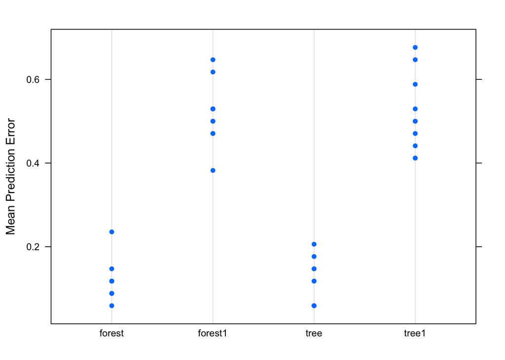

```r
dotplot(error~method, data=error_rates_two, ylab="Mean Prediction Error") # plot both defns of error for each                                                                              # model
```

This dot plot solidifies our above conclusions. Neither model is significantly better. Additionally, they are both mediocre when it comes to exactly predicting tournament placement. However, around 90% of the time they can predict at an accuracy of +/-1.

```r
lm(error~method, data=error_rates_two) %>% # show table of error data
  tidy() %>%
  knitr::kable()
```

| term | estimate | std.error | statistic | p.value |
| --- | --- | --- | --- | --- |
| (Intercept) | 0.1176471 | 0.0221241 | 5.3176008 | 0.0000057 |
| methodforest1 | 0.4000000 | 0.0312882 | 12.7843793 | 0.0000000 |
| methodtree | -0.0029412 | 0.0312882 | -0.0940028 | 0.9256282 |
| methodtree1 | 0.4000000 | 0.0312882 | 12.7843793 | 0.0000000 |

This table reinforces the conclusions we reached based on the dot plot.

## 4. Conclusions

We originally set out to create models which could boost a person’s likelihood of drawing up a successful March Madness bracket. We tidied our data, creating a data set where each entity was a college basketball team in a single season and kept the most relevant attributes, tweaking them to different data types when convenient. We used data vizualization to explore the relationships between attributes and found that there was linear correlation between all of our attributes and postseason performance. We then used cross validation to compare the accuracy of two classifications models: a decision tree and a random forest.

Based on our findings, neither model would allow us to pick a flawless bracket. However, our goal was to find a model that could help us build a **better** bracket, not a perfect one. This is why I chose to also evaluate how the models performed when a correct choice includes being off by a single round. In this case, both models’ performances become much better. Thus, while neither model is significantly different from the other, both have the potential to be useful tools when drawing up brackets, since they can certainly help narrow down which rounds a team may advance to.

## 5. Citations

[1] “Department of Mathematics.” [Online]. Available: https://math.duke.edu/news/duke-math-professor-says-odds-perfect-bracket-are-one-24-trillion. [Accessed: 18-May-2020].

[2] G. Grolemund, “Quick list of useful R packages,” RStudio Support, 11-May-2020. [Online]. Available: https://support.rstudio.com/hc/en-us/articles/201057987-Quick-list-of-useful-R-packages. [Accessed: 18-May-2020].

[3] N. T, “Difference Between Entity and Attribute in Database,” Binary Terms, 06-Apr-2020. [Online]. Available: https://binaryterms.com/difference-between-entity-and-attribute-in-database.html. [Accessed: 18-May-2020].

[4] A. Sundberg, “NCAA Data at https://www.kaggle.com/andrewsundberg/college-basketball-dataset.” Mar-2020.

[5] Mohityadav, “Understanding Data Attribute Types: Qualitative and Quantitative,” GeeksforGeeks, 06-Apr-2018. [Online]. Available: https://www.geeksforgeeks.org/understanding-data-attribute-types-qualitative-and-quantitative/. [Accessed: 18-May-2020].

[6] Centering and Scaling; When and when not? Sartorius Stedim Data Analytics, 2017.

[7] H. Wickham, “Create Elegant Data Visualisations Using the Grammar of Graphics,” Create Elegant Data Visualisations Using the Grammar of Graphics • ggplot2, 2016. [Online]. Available: https://ggplot2.tidyverse.org/. [Accessed: 18-May-2020].

[8] S. T. Kelly, “Violin Plot [R package vioplot version 0.3.4],” The Comprehensive R Archive Network, 29-Nov-2019. [Online]. Available: https://cran.r-project.org/web/packages/vioplot/index.html. [Accessed: 18-May-2020].

[9] M. R. Martinelli, “FTW Explains: Why do No. 11 seeds play in the First Four round of the NCAA tournament?,” USA Today, 13-Mar-2018. [Online]. Available: https://ftw.usatoday.com/2018/03/march-madness-ncaa-tournament-no-11-seed-first-four-play-in-16-bracket-rules-selection. [Accessed: 18-May-2020].

[10] J. Carron, “Violin Plots 101: Visualizing Distribution and Probability Density,” Violin Plots 101: Visualizing Distribution and Probability Density, 26-Oct-2016. [Online]. Available: https://mode.com/blog/violin-plot-examples/. [Accessed: 18-May-2020].

[11] “Conditional Probability,” Math Is Fun, 2017. [Online]. Available: https://www.mathsisfun.com/data/probability-events-conditional.html. [Accessed: 18-May-2020].

[12] P. Gupta, “Decision Trees in Machine Learning,” Medium, 12-Nov-2017. [Online]. Available: https://towardsdatascience.com/decision-trees-in-machine-learning-641b9c4e8052. [Accessed: 18-May-2020].

[13] Synced, “How Random Forest Algorithm Works in Machine Learning,” Medium, 25-Jun-2018. [Online]. Available: https://medium.com/@Synced/how-random-forest-algorithm-works-in-machine-learning-3c0fe15b6674. [Accessed: 18-May-2020].

[14] L. Breiman and A. Cutler, “Random Forests,” Random forests - classification description. [Online]. Available: https://www.stat.berkeley.edu/~breiman/RandomForests/cc_home.htm. [Accessed: 18-May-2020].

[15] J. Brownlee, “What is the Difference Between Test and Validation Datasets?,” Machine Learning Mastery, 26-Jul-2017. [Online]. Available: https://machinelearningmastery.com/difference-test-validation-datasets. [Accessed: 18-May-2020].

[16] J. Brownlee, “A Gentle Introduction to k-fold Cross-Validation,” Machine Learning Mastery, 08-Aug-2019. [Online]. Available: https://machinelearningmastery.com/k-fold-cross-validation/. [Accessed: 18-May-2020].